# Customers shopping analysis

Laura Won

# Analyzing Trends in Customer Behaviors

I decided to choose this topic for my future secondary career because the current job market is highly competitive, and I’m not sure when I will get hired. While waiting to get hired, and even after getting hired, I plan to become a small business owner as an online seller. Analyzing customer shopping preference data will give us insights into their preferences based on factors such as gender, age, items purchased, category, amount spent, location, size, color, season, discount promo codes applied, payment method, and purchase frequency. Analyzing customer shopping data will be crucial for understanding buying patterns and making informed decisions. This will allow me to understand shopping behavior patterns and apply data-driven insights for better decision-making as a seller.

## Shoppers’ Shopping Behavior Dataset

### Best-Selling Products in Online Stores

I want to see what would be the best selling items in online stores.

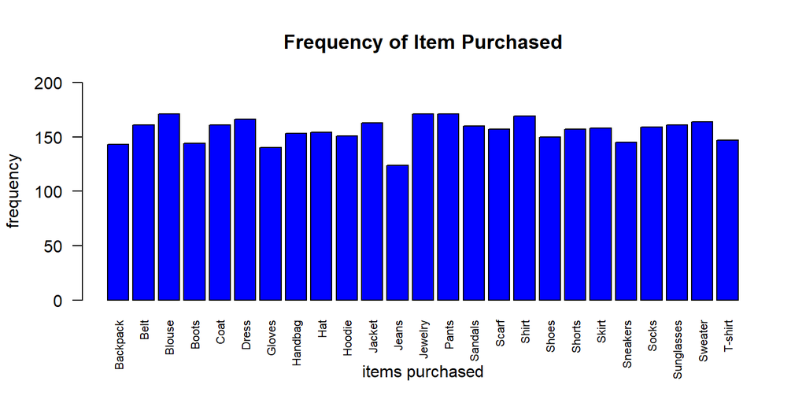

```r
shoppers <- read.csv(params$dataset_path)

#head(shoppers)

plot_colors <- params$plot_colors

#best selling items in barplot
best_selling_item <- table(shoppers$Item.Purchased)
barplot(best_selling_item,
        col=plot_colors[1],
        ylim=c(0,200),
        xlab="items purchased",
        ylab="frequency",
        main="Frequency of Item Purchased",
        las=2,
        cex.names=0.7)
```

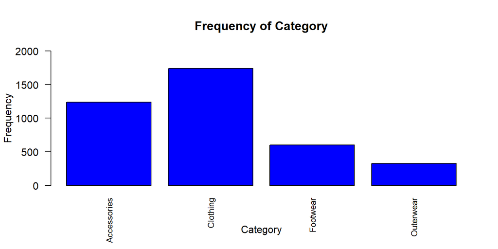

```r
#best selling category in barplot
best_seller_table <- table(shoppers$Category)
barplot(best_seller_table,
        col=plot_colors[1],
        ylim=c(0,2000),
        xlab="Category",
        ylab="Frequency",
        main="Frequency of Category",
        las=2,
        cex.names=0.8)
```

```r
#top5 best seller in clothing
clothing_data <- subset(shoppers, Category== "Clothing")
clothing_sales <- aggregate(Purchase.Amount..USD.~Item.Purchased, data=clothing_data, sum)
top_clothing_items <- clothing_sales[order(-clothing_sales$Purchase.Amount..USD.),][1:5,]
top_clothing_items
```

```
##    Item.Purchased Purchase.Amount..USD.
## 1          Blouse                 10410
## 6           Shirt                 10332
## 2           Dress                 10320
## 5           Pants                 10090
## 10        Sweater                  9462
```

```r
#top5 best seller in accessories
accessories_data <- subset(shoppers, Category=="Accessories")
accessories_sales <- aggregate(Purchase.Amount..USD. ~ Item.Purchased, data=accessories_data, sum)
top_accessories_item <- accessories_sales[order(-accessories_sales$Purchase.Amount..USD.),][1:5,]
top_accessories_item
```

```
##   Item.Purchased Purchase.Amount..USD.
## 6        Jewelry                 10010
## 8     Sunglasses                  9649
## 2           Belt                  9635
## 7          Scarf                  9561
## 5            Hat                  9375
```

I see that clothing is the top seller overall. Within clothing, blouses are selling the best for $10,410, and jewelry is $10,010 for the top seller in the accessories category.

## Gender distribution

Looking at gender distribution, what percentage of online shoppers are men and women?

### Gender ratio

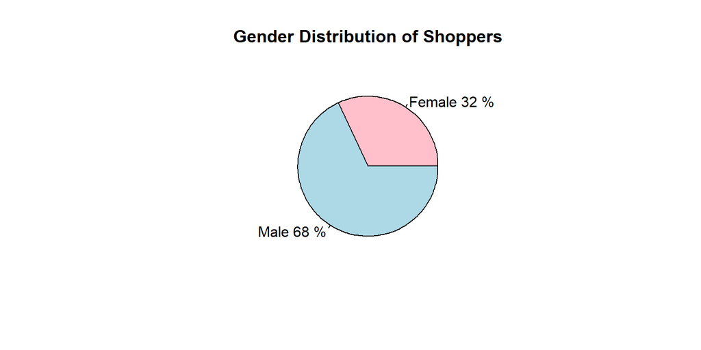

```r
#gender distribution
#remove NA values from shoppers$gender
shoppers$gender <- na.omit(shoppers$gender)
shoppers_gender_table <- table(shoppers$Gender)
gender_percentages <- round(100 * shoppers_gender_table / sum(shoppers_gender_table), 1)
pie_chart_labels <- paste(names(shoppers_gender_table), gender_percentages, "%", sep=" ")
pie(shoppers_gender_table, labels=pie_chart_labels, col=plot_colors[4:1], main="Gender Distribution of Shoppers")
```

Female shoppers make up 32% of the customer base, while males account for 68%. Is there a difference in the average purchase amount between male and female shoppers? Let’s see how average purchase amount varies by gender.

### Purchase amount by gender

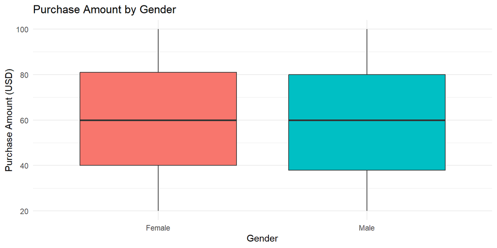

```r
#purchase amount by gender

library(ggplot2)

ggplot(shoppers, aes(x=Gender, y=Purchase.Amount..USD., fill=Gender)) +
  geom_boxplot() +
  labs(title="Purchase Amount by Gender", x="Gender", y="Purchase Amount (USD)") +
  theme_minimal() +
  theme(legend.position="none")
```

While the difference is relatively small, data suggests women spend a few dollars more on average per purchase.

### Frequency of Purchases by Gender

Analyzing purchase frequency, which gender exhibits a higher frequency of online shopping?

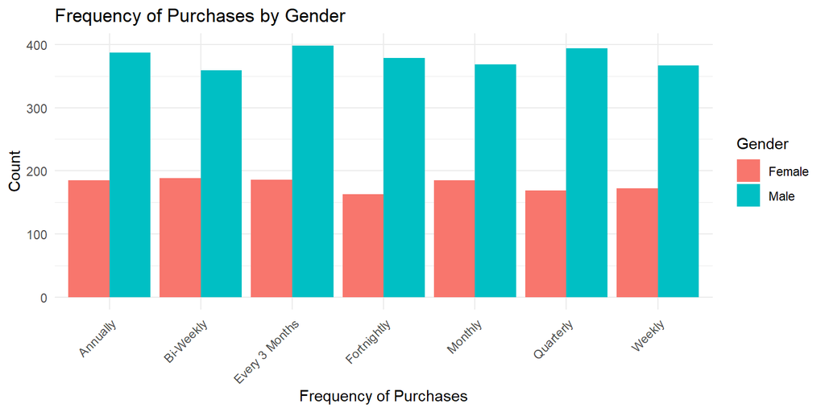

```r
#frequency of purchases by gender
library(dplyr)
cleaned_shoppers <- shoppers %>%
  filter(!is.na(Gender) & !is.na(Purchase.Amount..USD.) & !is.na(Promo.Code.Used))

frequency_gender <- cleaned_shoppers %>%
  group_by(Gender, Frequency.of.Purchases) %>%
  summarise(count = n()) %>%
  arrange(Gender, Frequency.of.Purchases)

ggplot(frequency_gender, aes(x=Frequency.of.Purchases, y=count, fill=Gender)) +
  geom_bar(stat="identity", position="dodge") +
  labs(title="Frequency of Purchases by Gender",
       x="Frequency of Purchases",
       y="Count",
       fill="Gender") +
  theme_minimal() +
  theme(axis.text.x = element_text(angle=45, hjust=1))
```

Generally, men shop twice as often as women.

### What male shoppers normally buy?

Now that we know men shop more frequently, let’s explore what they typically purchase.

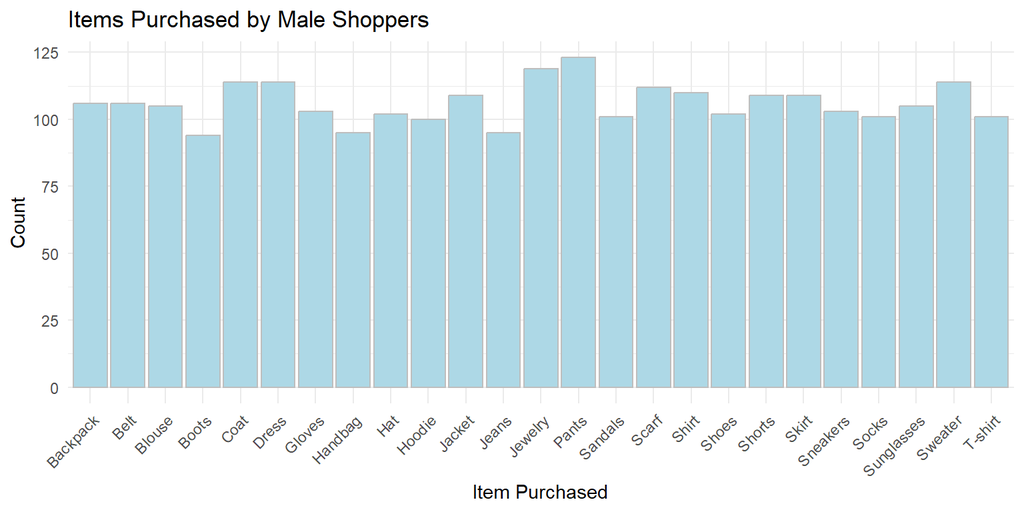

```r
#filter the data for male shoppers
male_shoppers <- cleaned_shoppers %>%
  filter(Gender == "Male")

#create a histogram of items purchased by male shoppers
ggplot(male_shoppers, aes(x = Item.Purchased, fill = Item.Purchased)) +
  geom_histogram(stat = "count", fill = plot_colors[3], color = plot_colors[2], bins = 30) +
  labs(title = "Items Purchased by Male Shoppers",
       x = "Item Purchased",
       y = "Count") +
  theme_minimal() +
  theme(axis.text.x = element_text(angle = 45, hjust = 1))
```

Pants are the most popular items purchased by male shoppers. Compared to the general clothing category, blouses are the top seller, and they fall under women’s clothing. Even though there are fewer female shoppers than males, women might spend more money on average due to buying blouses. For those seeking a reliable customer base with a consistent purchase item, male shoppers buying pants would be a good target audience.

### Interpretations of the features

Let’s find out relationships of numerous features. Age, purchase amount$, review rating, and previous purchases

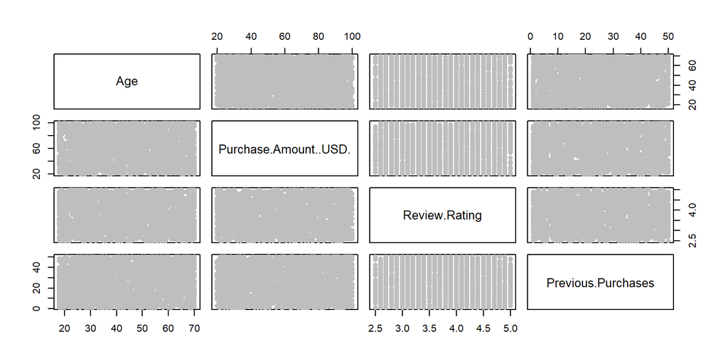

```r
male_shoppers <- cleaned_shoppers %>%
  filter(Gender == "Male")

numeric_columns <- c('Age', 'Purchase.Amount..USD.', 'Review.Rating', 'Previous.Purchases')

shopper_male_selected <- male_shoppers[, numeric_columns]

pairs(shopper_male_selected, pch = 16, col = plot_colors[2])
```

```r
pairs_cm <- round(cor(shopper_male_selected), 2)
pairs_cm
```

```
##                         Age Purchase.Amount..USD. Review.Rating
## Age                    1.00                 -0.01         -0.02
## Purchase.Amount..USD. -0.01                  1.00          0.04
## Review.Rating         -0.02                  0.04          1.00
## Previous.Purchases     0.05                  0.01         -0.01
##                       Previous.Purchases
## Age                                 0.05
## Purchase.Amount..USD.               0.01
## Review.Rating                      -0.01
## Previous.Purchases                  1.00
```

## Sampling methods

### Central Limit Theorem

Using 1000 samples of size 50 from the population data, calculate the mean of each sample to determine the highest frequency shopping budget in terms of the mean purchase amount (USD).

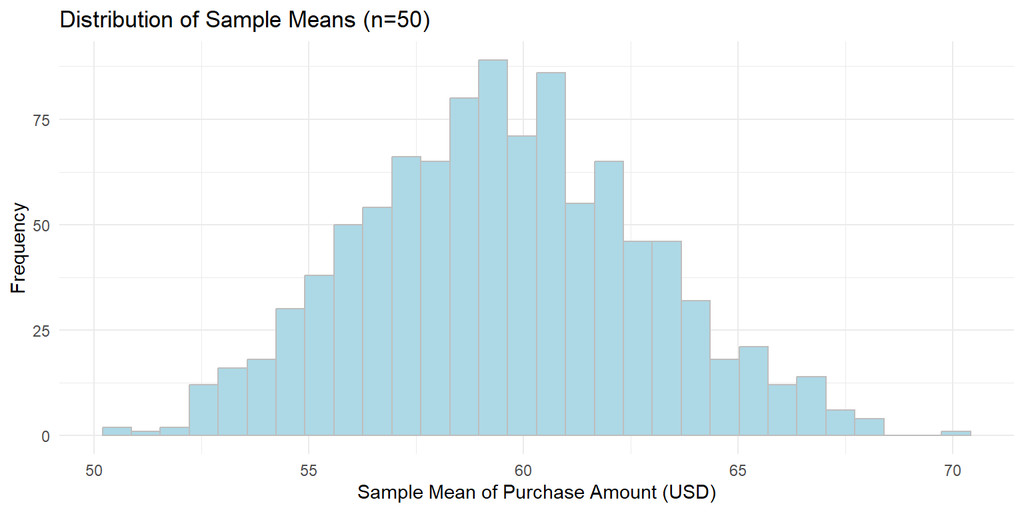

```r
set.seed(params$seed)
sample_means <- replicate(1000, mean(sample(shopper_male_selected$Purchase.Amount..USD., params$sample_size, replace = TRUE)))
ggplot(data.frame(sample_means), aes(x = sample_means)) +
  geom_histogram(bins = 30, fill = plot_colors[3], color = plot_colors[2]) +
  labs(title = "Distribution of Sample Means (n=50)",
       x = "Sample Mean of Purchase Amount (USD)",
       y = "Frequency") +
  theme_minimal()
```

Around $58,$59 is the sample mean of the purchase amount for the highest frequency in shopping.

### Simple Random Sampling

Let’s see what would be different in sampling methods.

```r
set.seed(123)  #set.seed(params$seed) I tried to use it to avoid hardcoding, but it constantly changed value.
sample_size <- 100 #sample_size <- params$sample_size  not returning consistent outcome

simple_random_sample <- shoppers[sample(nrow(shoppers), sample_size, replace = FALSE), ]

str(simple_random_sample)
```

```
## 'data.frame':    100 obs. of  18 variables:
##  $ Customer.ID           : int  2463 2511 2227 526 195 2986 1842 1142 3371 1253 ...
##  $ Age                   : int  68 40 22 51 51 46 31 39 30 28 ...
##  $ Gender                : chr  "Male" "Male" "Male" "Male" ...
##  $ Item.Purchased        : chr  "Pants" "Jacket" "Shirt" "Coat" ...
##  $ Category              : chr  "Clothing" "Outerwear" "Clothing" "Outerwear" ...
##  $ Purchase.Amount..USD. : int  99 42 72 37 94 36 57 33 31 41 ...
##  $ Location              : chr  "Missouri" "South Dakota" "Missouri" "Iowa" ...
##  $ Size                  : chr  "XL" "L" "L" "M" ...
##  $ Color                 : chr  "Orange" "Purple" "Blue" "Cyan" ...
##  $ Season                : chr  "Spring" "Winter" "Spring" "Spring" ...
##  $ Review.Rating         : num  4.3 4.4 4.8 3.2 3.1 3 3 4.7 2.8 4 ...
##  $ Subscription.Status   : chr  "No" "No" "No" "Yes" ...
##  $ Shipping.Type         : chr  "Standard" "Standard" "Store Pickup" "Next Day Air" ...
##  $ Discount.Applied      : chr  "No" "No" "No" "Yes" ...
##  $ Promo.Code.Used       : chr  "No" "No" "No" "Yes" ...
##  $ Previous.Purchases    : int  31 48 28 41 15 21 7 23 46 8 ...
##  $ Payment.Method        : chr  "Bank Transfer" "Credit Card" "Cash" "Debit Card" ...
##  $ Frequency.of.Purchases: chr  "Bi-Weekly" "Weekly" "Annually" "Monthly" ...
```

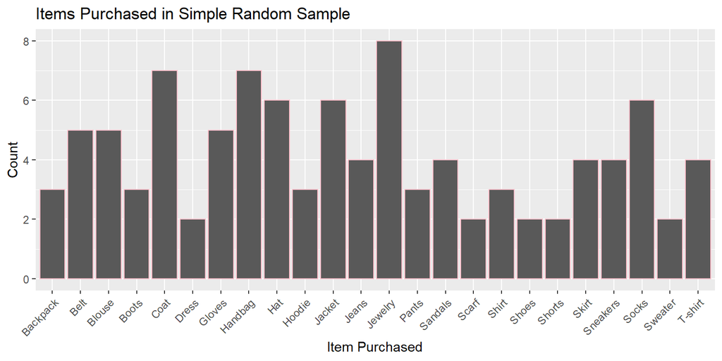

```r
library(ggplot2)
ggplot(simple_random_sample, aes(x = Item.Purchased)) +
  geom_bar(color = plot_colors[4]) +
  labs(title = "Items Purchased in Simple Random Sample",
       x = "Item Purchased",
       y = "Count") +
  theme(axis.text.x = element_text(angle = 45, hjust = 1))
```

Jewelry is the highest purchased in simple random sample.

### Stratified Sampling

Gender-based differences in purchase amount

```r
strata <- c("Male", "Female")
stratum_sample_size <- 50 #params$sample_size<- tried use for avoid hardcoding, but not returning consistent outcome

stratified_sample <- shoppers %>%
  group_by(Gender) %>%
  sample_n(size = stratum_sample_size, replace = FALSE)

str(stratified_sample)
```

```
## gropd_df [100 × 18] (S3: grouped_df/tbl_df/tbl/data.frame)
##  $ Customer.ID           : int [1:100] 3189 3635 2943 3323 2773 3786 3834 3740 3132 2719 ...
##  $ Age                   : int [1:100] 42 59 54 52 18 64 44 38 34 22 ...
##  $ Gender                : chr [1:100] "Female" "Female" "Female" "Female" ...
##  $ Item.Purchased        : chr [1:100] "Blouse" "Socks" "Socks" "Sweater" ...
##  $ Category              : chr [1:100] "Clothing" "Clothing" "Clothing" "Clothing" ...
##  $ Purchase.Amount..USD. : int [1:100] 59 22 63 92 94 94 93 31 59 90 ...
##  $ Location              : chr [1:100] "Vermont" "Ohio" "Hawaii" "Indiana" ...
##  $ Size                  : chr [1:100] "M" "M" "M" "XL" ...
##  $ Color                 : chr [1:100] "Lavender" "Pink" "Brown" "Orange" ...
##  $ Season                : chr [1:100] "Winter" "Winter" "Summer" "Winter" ...
##  $ Review.Rating         : num [1:100] 3.5 3.3 2.6 4.6 3.5 3.8 4.6 4.2 2.9 4.9 ...
##  $ Subscription.Status   : chr [1:100] "No" "No" "No" "No" ...
##  $ Shipping.Type         : chr [1:100] "Standard" "Standard" "Free Shipping" "Next Day Air" ...
##  $ Discount.Applied      : chr [1:100] "No" "No" "No" "No" ...
##  $ Promo.Code.Used       : chr [1:100] "No" "No" "No" "No" ...
##  $ Previous.Purchases    : int [1:100] 39 17 37 43 10 6 17 43 11 10 ...
##  $ Payment.Method        : chr [1:100] "Bank Transfer" "PayPal" "Bank Transfer" "PayPal" ...
##  $ Frequency.of.Purchases: chr [1:100] "Monthly" "Annually" "Weekly" "Weekly" ...
##  - attr(*, "groups")= tibble [2 × 2] (S3: tbl_df/tbl/data.frame)
##   ..$ Gender: chr [1:2] "Female" "Male"
##   ..$ .rows : list<int> [1:2]
##   .. ..$ : int [1:50] 1 2 3 4 5 6 7 8 9 10 ...
##   .. ..$ : int [1:50] 51 52 53 54 55 56 57 58 59 60 ...
##   .. ..@ ptype: int(0)
##   ..- attr(*, ".drop")= logi TRUE
```

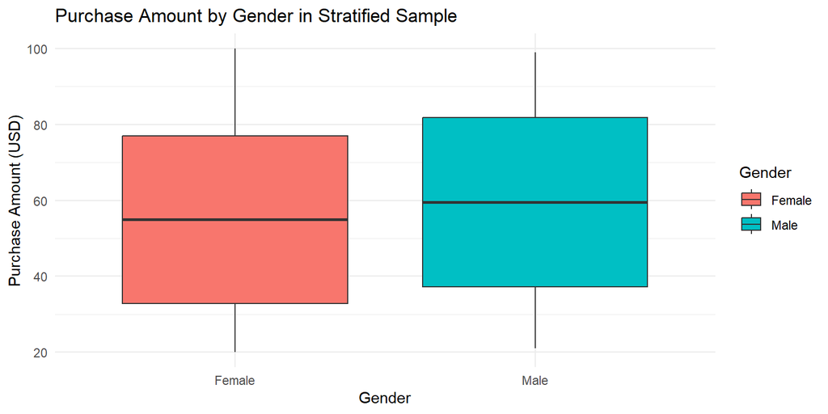

```r
#create a boxplot of purchase amounts by gender
ggplot(stratified_sample, aes(x = Gender, y = Purchase.Amount..USD., fill = Gender)) +
  geom_boxplot() +
  labs(title = "Purchase Amount by Gender in Stratified Sample",
       x = "Gender",
       y = "Purchase Amount (USD)") +
  theme_minimal()
```

Therefore, samples can be a powerful tool for analysis, it’s important to ensure they are chosen carefully to represent the entire population.

## Wrangling Techniques

### Best selling color and size

Let’s identify the best-selling colors and sizes to minimize the risk of excess inventory.

```r
library(tibble)

male_preference <- as_tibble(male_shoppers)

male_preference
```

```
## # A tibble: 2,652 × 18
##    Customer.ID   Age Gender Item.Purchased Category    Purchase.Amount..USD.
##          <int> <int> <chr>  <chr>          <chr>                       <int>
##  1           1    55 Male   Blouse         Clothing                       53
##  2           2    19 Male   Sweater        Clothing                       64
##  3           3    50 Male   Jeans          Clothing                       73
##  4           4    21 Male   Sandals        Footwear                       90
##  5           5    45 Male   Blouse         Clothing                       49
##  6           6    46 Male   Sneakers       Footwear                       20
##  7           7    63 Male   Shirt          Clothing                       85
##  8           8    27 Male   Shorts         Clothing                       34
##  9           9    26 Male   Coat           Outerwear                      97
## 10          10    57 Male   Handbag        Accessories                    31
## # ℹ 2,642 more rows
## # ℹ 12 more variables: Location <chr>, Size <chr>, Color <chr>, Season <chr>,
## #   Review.Rating <dbl>, Subscription.Status <chr>, Shipping.Type <chr>,
## #   Discount.Applied <chr>, Promo.Code.Used <chr>, Previous.Purchases <int>,
## #   Payment.Method <chr>, Frequency.of.Purchases <chr>
```

```r
glimpse(male_shoppers)
```

```
## Rows: 2,652
## Columns: 18
## $ Customer.ID            <int> 1, 2, 3, 4, 5, 6, 7, 8, 9, 10, 11, 12, 13, 14, …
## $ Age                    <int> 55, 19, 50, 21, 45, 46, 63, 27, 26, 57, 53, 30,…
## $ Gender                 <chr> "Male", "Male", "Male", "Male", "Male", "Male",…
## $ Item.Purchased         <chr> "Blouse", "Sweater", "Jeans", "Sandals", "Blous…
## $ Category               <chr> "Clothing", "Clothing", "Clothing", "Footwear",…
## $ Purchase.Amount..USD.  <int> 53, 64, 73, 90, 49, 20, 85, 34, 97, 31, 34, 68,…
## $ Location               <chr> "Kentucky", "Maine", "Massachusetts", "Rhode Is…
## $ Size                   <chr> "L", "L", "S", "M", "M", "M", "M", "L", "L", "M…
## $ Color                  <chr> "Gray", "Maroon", "Maroon", "Maroon", "Turquois…
## $ Season                 <chr> "Winter", "Winter", "Spring", "Spring", "Spring…
## $ Review.Rating          <dbl> 3.1, 3.1, 3.1, 3.5, 2.7, 2.9, 3.2, 3.2, 2.6, 4.…
## $ Subscription.Status    <chr> "Yes", "Yes", "Yes", "Yes", "Yes", "Yes", "Yes"…
## $ Shipping.Type          <chr> "Express", "Express", "Free Shipping", "Next Da…
## $ Discount.Applied       <chr> "Yes", "Yes", "Yes", "Yes", "Yes", "Yes", "Yes"…
## $ Promo.Code.Used        <chr> "Yes", "Yes", "Yes", "Yes", "Yes", "Yes", "Yes"…
## $ Previous.Purchases     <int> 14, 2, 23, 49, 31, 14, 49, 19, 8, 4, 26, 10, 37…
## $ Payment.Method         <chr> "Venmo", "Cash", "Credit Card", "PayPal", "PayP…
## $ Frequency.of.Purchases <chr> "Fortnightly", "Fortnightly", "Weekly", "Weekly…
```

```r
library(dplyr)
#best selling color for male shoppers
best_color <- male_shoppers %>%
  group_by(Color) %>%
  summarise(total_sales = n()) %>%
  arrange(desc(total_sales)) %>%
  slice(1)  # Select the top-selling color

best_color
```

```
## # A tibble: 1 × 2
##   Color  total_sales
##   <chr>        <int>
## 1 Silver         121
```

```r
#best selling size for male shoppers
best_size <- male_shoppers %>%
  group_by(Size) %>%
  summarise(total_sales = n()) %>%
  arrange(desc(total_sales)) %>%
  slice(1)  # Select the top-selling size

best_size
```

```
## # A tibble: 1 × 2
##   Size  total_sales
##   <chr>       <int>
## 1 M            1165
```

```r
#see sales numbers in colors
color_sales <- male_shoppers %>%
  group_by(Color) %>%
  summarise(total_sales = n()) %>%
  arrange(desc(total_sales))
color_sales
```

```
## # A tibble: 25 × 2
##    Color  total_sales
##    <chr>        <int>
##  1 Silver         121
##  2 Cyan           119
##  3 Teal           119
##  4 Olive          118
##  5 Yellow         114
##  6 Black          113
##  7 Green          113
##  8 Violet         113
##  9 Purple         109
## 10 Beige          107
## # ℹ 15 more rows
```

```r
color_size_counts <- male_shoppers %>%
  group_by(Size, Color) %>%
  summarise(total_sales = n()) %>%
  arrange(Size, desc(total_sales))
```

Based on the color and size counts, silver color and size medium is the best selling. And silver and cyan, teal and olive has not too different in total sales.

# Plots for color and size in total sales

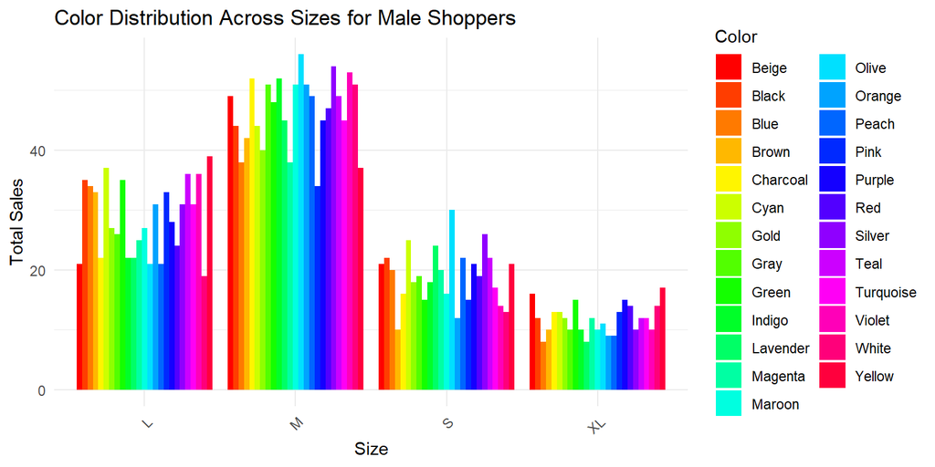

```r
unique_colors <- unique(color_size_counts$Color)

custom_palette <- rainbow(length(unique_colors))

ggplot(color_size_counts, aes(x = Size, y = total_sales, fill = Color)) +
  geom_bar(stat = "identity", position = "dodge") +
  labs(title = "Color Distribution Across Sizes for Male Shoppers",
       x = "Size",
       y = "Total Sales",
       fill = "Color") +
  scale_fill_manual(values = custom_palette) +  # Apply custom color palette
  theme_minimal() +
  theme(axis.text.x = element_text(angle = 45, hjust = 1),
        legend.position = "right")
```

It may seem like olive has the highest sales in the medium size. However, considering total sales across all colors, silver is the best seller.

# Conclusions

By analyzing customer shopping behavior data, we gained valuable insights that can be applied to online store operations. We discovered that:

### Clothing is the top-selling category,

with blouses leading the pack for women and jewelry for accessories.

### Men shop more frequently

than women, but women spend slightly more per purchase on average.

### Pants are the most popular item among male shoppers,

but the connection isn’t very strong.

### Sampling methods can yield different results

compared to the entire dataset.

### Silver is the overall best-selling color,

while medium is the most popular size. However, other colors like olive and cyan show promising sales potential.

These findings suggest that targeting strategies should consider both gender and product preferences. While men might be a larger customer base due to purchase frequency, focusing on women’s higher average spending power with targeted clothing choices like blouses could be equally beneficial.

Overall, data-driven analysis of customer behavior allows us to make informed decisions regarding inventory management, product offerings, and marketing strategies to optimize online store success.